# [eb3] Analyses

Egor Ananyev

2020-04-13

# Data input and parsing

```r
options(width=100)
# options(width=90)
out=F
library(plyr)
library(dplyr)
library(ggplot2)
library(lme4)
library(reshape2)
computer = 'acer'  # 'shocky', 'station3', 'acer' are all possible options
if(computer=='shocky' || computer=='acer'){ cloud_dir='C:/gd/' }
# if(computer=='shocky'){ cloud_dir='C:/Users/Egor/Dropbox/' }
# if(computer=='acer' || computer == 'toshi'){ cloud_dir = 'C:/Users/egora/Dropbox/' }
if(computer=='station3'){ cloud_dir='/home/station3/Desktop/Egor/Dropbox/' }
# source(paste(cloud_dir, 'Projects/eb/eb/an/funs_an/BF_t.R', sep='/'))
# source(paste(cloud_dir, 'Projects/eb/eb/an/funs_an/BF_U.R', sep='/'))
library(R.utils)
sourceDirectory(paste(cloud_dir, 'Projects/eb/eb/an/funs_an', sep='/'))
source(paste('C:/gd/', 'Prog/R/myFunctions/pvalfn.R', sep=''))
ds = read.csv(paste(cloud_dir, 'Projects/eb/eb/an/consolidated/ds3.csv', sep='/'))
dsa = read.csv(paste(cloud_dir, 'Projects/eb/eb/an/consolidated/dsa3.csv', sep='/'))
# Reordering levels of Condition variable, such that No Blink condition is the reference:
ds$Cond = factor(ds$Cond, c('NoBlink','Artificial','Prompted'))
ds$CondFull = factor(ds$CondFull, c('No Blink','Artificial Blink','Prompted Blink'))
cue_valid_name = 'Cue Validity'
```

# Cueing

## Boxplots

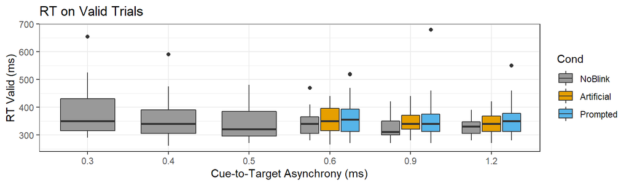

```r
ss_corr = ds[ds$corr_resp==1, ]
ctoa_valid = ddply(ss_corr[ss_corr$CueValid=='Valid',], .(targ_soa, Cond, subj), summarise,
                   RT=median(RT))
plot_box_ctoa(ctoa_valid, 'RT Valid (ms)', 'RT on Valid Trials', out, 'targ_soa', eb='eb3')
```

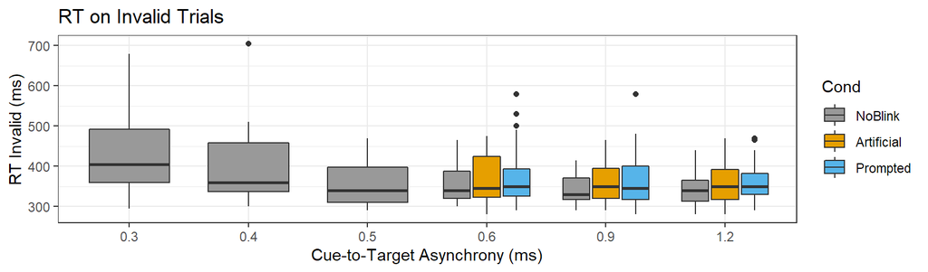

```r
ctoa_invalid = ddply(ss_corr[ss_corr$CueValid=='Invalid',], .(targ_soa, Cond, subj), summarise,
                  RT=median(RT))
plot_box_ctoa(ctoa_invalid, 'RT Invalid (ms)', 'RT on Invalid Trials', out, 'targ_soa', eb='eb3')
```

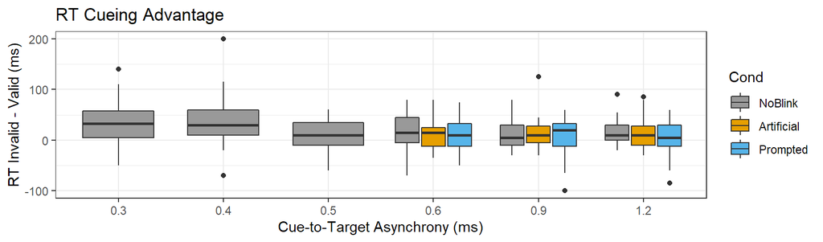

```r
ctoa_adv = merge(ctoa_valid, ctoa_invalid, by=c('targ_soa', 'Cond', 'subj'))
ctoa_adv$RT = ctoa_adv$RT.y - ctoa_adv$RT.x  # Invalid - Valid RT
plot_box_ctoa(ctoa_adv, 'RT Invalid - Valid (ms)', 'RT Cueing Advantage', out, 'targ_soa', eb='eb3')
```

# Data sets

Late CTOA data set:

```r
ss_late = ds[ds$targ_soa > 0.5, ]
ss_late$CTOA = factor(ss_late$targ_soa)
ss_late$targ_soa_c = ss_late$targ_soa - .9
ss_late$targ_soa_0 = ss_late$targ_soa - .6
ss_late$incorr = 1 - ss_late$corr_resp
```

Adding early NB cueing:

```r
ss_early = ds[ds$targ_soa <= 0.5, ]
ss_early_val = ddply(ss_early[ss_early$CueValid=='Valid',], .(subj), summarise,
                     RT_val = median(RT))
ss_early_inv = ddply(ss_early[ss_early$CueValid=='Invalid',], .(subj), summarise,
                     RT_inv = median(RT))
ss_early_adv = merge(ss_early_val, ss_early_inv, by=c('subj'))
ss_early_adv$RT_early_adv = ss_early_adv$RT_inv - ss_early_adv$RT_val  # Invalid - Valid RT
```

```r
ss_late = merge(ss_late, ss_early_adv[ , c('subj', 'RT_early_adv')], by='subj')
head(ss_late)
```

```
##   subj exp_name cue_pred cond block trial cue_delay targ_right cue_valid targ_soa shutter_dur
## 1    1      eb3        1    a     1     1     0.320          1         1      0.9   0.1846928
## 2    1      eb3        1    a     1     3     0.315          0         1      0.9   0.2582307
## 3    1      eb3        1    a     1     4     0.436          0         1      0.9   0.2544424
## 4    1      eb3        1    a     1     6     0.447          1         1      0.9   0.1812708
## 5    1      eb3        1    a     1     8     0.385          1         0      0.9   0.2488420
## 6    1      eb3        1    a     1     9     0.373          1         0      0.9   0.2561694
##   trial_start trial_end    cue_rt corr_resp        rt block_date block_time block_order       Cond
## 1    167.5719  169.8319 0.4300270         1 0.4399490 2020-03-12       1143           1 Artificial
## 2    174.2521  176.2620 0.3300130         1 0.2999969 2020-03-12       1143           1 Artificial
## 3    177.0920  182.7120 0.8200240         1 0.5199821 2020-03-12       1143           1 Artificial
## 4    186.6020  189.3721 0.3400300         1 0.2899611 2020-03-12       1143           1 Artificial
## 5    193.4721  195.5321 0.3799689         1 0.3300331 2020-03-12       1143           1 Artificial
## 6    196.3621  200.3922 0.3700140         1 0.3098929 2020-03-12       1143           1 Artificial
##           CondFull    CuePred    CuePredFull CueValid cue_valid_c cue_pred_c       RT CTOA
## 1 Artificial Blink Predictive Predictive Cue    Valid           1          1 439.9490  0.9
## 2 Artificial Blink Predictive Predictive Cue    Valid           1          1 299.9969  0.9
## 3 Artificial Blink Predictive Predictive Cue    Valid           1          1 519.9821  0.9
## 4 Artificial Blink Predictive Predictive Cue    Valid           1          1 289.9611  0.9
## 5 Artificial Blink Predictive Predictive Cue  Invalid          -1          1 330.0331  0.9
## 6 Artificial Blink Predictive Predictive Cue  Invalid          -1          1 309.8929  0.9
##   targ_soa_c targ_soa_0 incorr RT_early_adv
## 1          0        0.3      0     29.97017
## 2          0        0.3      0     29.97017
## 3          0        0.3      0     29.97017
## 4          0        0.3      0     29.97017
## 5          0        0.3      0     29.97017
## 6          0        0.3      0     29.97017
```

```r
ss_late_corr = ss_late[ss_late$corr_resp==1, ]
ss_late_incorr = ss_late[ss_late$corr_resp==0, ]
```

Recording per-subject accuracy:

```r
acc_ds = merge(ss_late, ddply(ds, .(subj), summarise, inacc = (1 - mean(corr_resp)) * 100), by='subj')
```

Blink duration:

```r
dsa$bdur = dsa$tot_blank_time
bdur_sumss = ddply(dsa, .(Cond, subj), summarize,
                        bdur_ave = mean(bdur),
                        bdur_sd = sd(bdur))
dsa = merge(dsa, bdur_sumss, by=c('Cond', 'subj'))
dsa$bdur_z = with(dsa, (bdur - bdur_ave) / bdur_sd)
```

Blink latency:

```r
dsa$blat = dsa$blank_time_beg - (dsa$cue_time - dsa$trial_time_beg)
blat_sumss = ddply(dsa, .(Cond, subj), summarize,
                        blat_ave = mean(blat),
                        blat_sd = sd(blat))
dsa = merge(dsa, blat_sumss, by=c('Cond', 'subj'))
dsa$blat_z = with(dsa, (blat - blat_ave) / blat_sd)
```

# Basic (nuisance-free) model

## CTOA as factor:

```r
print(lmerfn(lmer(RT ~ cue_valid * Cond * CTOA + (1|subj), data = ss_late_corr)))
```

```
##                                     estm     se   tVal star num
## (Intercept)                      366.285 10.404 35.208  ***   0
## cue_valid                        -13.992  5.473 -2.556    *   1
## CondArtificial                     6.186  7.193  0.860        2
## CondPrompted                      19.280  6.991  2.758    *   3
## CTOA0.9                          -18.532  6.724 -2.756    *   4
## CTOA1.2                          -14.052  6.710 -2.094    *   5
## cue_valid:CondArtificial           6.298  8.235  0.765        6
## cue_valid:CondPrompted             7.208  8.054  0.895        7
## cue_valid:CTOA0.9                  4.189  7.748  0.541        8
## cue_valid:CTOA1.2                  3.089  7.727  0.400        9
## CondArtificial:CTOA0.9            10.430  9.922  1.051       10
## CondPrompted:CTOA0.9               7.819  9.796  0.798       11
## CondArtificial:CTOA1.2             3.192  9.950  0.321       12
## CondPrompted:CTOA1.2              -0.619  9.768 -0.063       13
## cue_valid:CondArtificial:CTOA0.9  -4.563 11.414 -0.400       14
## cue_valid:CondPrompted:CTOA0.9    -2.726 11.298 -0.241       15
## cue_valid:CondArtificial:CTOA1.2  -6.577 11.421 -0.576       16
## cue_valid:CondPrompted:CTOA1.2     1.298 11.257  0.115       17
```

Same model but without outliers 20 and 24:

```r
print(lmerfn(lmer(RT ~ cue_valid * Cond * CTOA + (1|subj),
                  data = ss_late_corr[!ss_late_corr$subj %in% c(20,24), ])))
```

```
##                                     estm     se   tVal star num
## (Intercept)                      362.370  9.888 36.647  ***   0
## cue_valid                        -12.546  5.534 -2.267    *   1
## CondArtificial                     7.980  7.309  1.092        2
## CondPrompted                       9.480  7.038  1.347        3
## CTOA0.9                          -20.697  6.794 -3.047    *   4
## CTOA1.2                          -14.576  6.787 -2.148    *   5
## cue_valid:CondArtificial           3.101  8.363  0.371        6
## cue_valid:CondPrompted             9.312  8.112  1.148        7
## cue_valid:CTOA0.9                  2.451  7.827  0.313        8
## cue_valid:CTOA1.2                  2.728  7.812  0.349        9
## CondArtificial:CTOA0.9            13.414 10.063  1.333       10
## CondPrompted:CTOA0.9               9.159  9.863  0.929       11
## CondArtificial:CTOA1.2             3.152 10.100  0.312       12
## CondPrompted:CTOA1.2               4.767  9.857  0.484       13
## cue_valid:CondArtificial:CTOA0.9  -1.236 11.572 -0.107       14
## cue_valid:CondPrompted:CTOA0.9    -6.360 11.382 -0.559       15
## cue_valid:CondArtificial:CTOA1.2  -3.444 11.588 -0.297       16
## cue_valid:CondPrompted:CTOA1.2    -6.012 11.359 -0.529       17
```

## CTOA as numeric:

```r
print(lmerfn(lmer(RT ~ cue_valid_c * Cond * targ_soa + (1|subj), data = ss_late_corr)))
```

```
##                                        estm     se   tVal star num
## (Intercept)                         368.405 11.033 33.392  ***   0
## cue_valid_c                          -8.067  6.014 -1.341        1
## CondArtificial                       11.982  8.946  1.339        2
## CondPrompted                         24.813  8.798  2.820    *   3
## targ_soa                            -20.821  6.443 -3.232    *   4
## cue_valid_c:CondArtificial            6.312  8.944  0.706        5
## cue_valid_c:CondPrompted              2.351  8.795  0.267        6
## cue_valid_c:targ_soa                  2.551  6.442  0.396        7
## CondArtificial:targ_soa              -0.030  9.519 -0.003        8
## CondPrompted:targ_soa                 0.212  9.387  0.023        9
## cue_valid_c:CondArtificial:targ_soa  -5.555  9.517 -0.584       10
## cue_valid_c:CondPrompted:targ_soa     1.121  9.383  0.120       11
```

## Looking only at CTOA = 900

```r
ss_900 = ss_late_corr[ss_late_corr$CTOA==0.9,]
print(lmerfn(lmer(RT ~ cue_valid * Cond + block + targ_right + (1|subj), data = ss_900)))
```

```
##                             estm     se   tVal star num
## (Intercept)              347.953 11.963 29.086  ***   0
## cue_valid                 -9.615  5.311 -1.810        1
## CondArtificial            15.985  6.941  2.303    *   2
## CondPrompted              26.438  6.930  3.815    *   3
## block                     -0.458  1.614 -0.284        4
## targ_right                 2.589  2.732  0.948        5
## cue_valid:CondArtificial   1.527  7.652  0.200        6
## cue_valid:CondPrompted     5.011  7.675  0.653        7
```

Same but without the two outlier subjects:

```r
print(lmerfn(lmer(RT ~ cue_valid * Cond + block + targ_right + (1|subj),
                  data = ss_900[!ss_900$subj %in% c(20,24), ])))
```

```
##                             estm     se   tVal star num
## (Intercept)              340.454 10.968 31.041  ***   0
## cue_valid                 -9.885  5.154 -1.918    ~   1
## CondArtificial            21.539  6.839  3.150    *   2
## CondPrompted              18.304  6.760  2.708    *   3
## block                      0.028  1.564  0.018        4
## targ_right                 2.288  2.657  0.861        5
## cue_valid:CondArtificial   1.592  7.447  0.214        6
## cue_valid:CondPrompted     3.652  7.438  0.491        7
```

```r
ddply(ss_900, .(Cond, cue_valid), summarize, RT_mean=mean(RT), RT_median=median(RT))
```

```
##         Cond cue_valid  RT_mean RT_median
## 1    NoBlink         0 347.5051  330.0276
## 2    NoBlink         1 337.4699  320.0049
## 3 Artificial         0 362.6163  340.0770
## 4 Artificial         1 355.9057  339.9959
## 5   Prompted         0 372.1725  340.0490
## 6   Prompted         1 368.5053  340.0040
```

```r
ddply(ctoa_adv[ctoa_adv$targ_soa==0.9,], .(Cond), summarize, RT_mean=mean(RT), RT_median=median(RT))
```

```
##         Cond   RT_mean RT_median
## 1    NoBlink 14.113089  4.991531
## 2 Artificial 12.616738 10.002017
## 3   Prompted  7.617391 19.994974
```

The means and the medians tell the opposite story. Might necessitate some data transformation. Although the linear models should be resillient to the individual differences in RT.

# Cueing ~ accuracy

The following model type results in rank deficiency due to insufficient number of incorrect trials:

```r
# print(lmerfn(lmer(RT ~ cue_valid * Cond * CTOA + (1|subj), data = ss_late_incorr)))
```

The full model yields nothing significant:

```r
head(lmerfn(lmer(RT ~ cue_valid * Cond * CTOA * inacc + block + (1|subj), data = acc_ds)), 10)
```

```
##                             estm     se   tVal star num
## (Intercept)              386.701 14.300 27.042  ***   0
## cue_valid                -16.401  7.188 -2.282    *   1
## CondArtificial            -6.393  9.487 -0.674        2
## CondPrompted              18.227  9.252  1.970    ~   3
## CTOA0.9                  -24.252  8.854 -2.739    *   4
## CTOA1.2                  -15.454  8.832 -1.750        5
## inacc                    -10.925  9.092 -1.202        6
## block                     -2.934  0.707 -4.153   **   7
## cue_valid:CondArtificial   7.339 10.817  0.678        8
## cue_valid:CondPrompted     4.791 10.589  0.452        9
```

```r
print('...other effects (nonsignificant)...')
```

```
## [1] "...other effects (nonsignificant)..."
```

```r
print(lmerfn(lmer(RT ~ cue_valid * Cond * inacc * CTOA + block + (1|subj), data = acc_ds)))
```

```
##                                           estm     se   tVal star num
## (Intercept)                            386.701 14.300 27.042  ***   0
## cue_valid                              -16.401  7.188 -2.282    *   1
## CondArtificial                          -6.393  9.487 -0.674        2
## CondPrompted                            18.227  9.252  1.970    ~   3
## inacc                                  -10.925  9.092 -1.202        4
## CTOA0.9                                -24.252  8.854 -2.739    *   5
## CTOA1.2                                -15.454  8.832 -1.750        6
## block                                   -2.934  0.707 -4.153   **   7
## cue_valid:CondArtificial                 7.339 10.817  0.678        8
## cue_valid:CondPrompted                   4.791 10.589  0.452        9
## cue_valid:inacc                          3.487  4.752  0.734       10
## CondArtificial:inacc                     8.394  6.354  1.321       11
## CondPrompted:inacc                      -4.894  6.096 -0.803       12
## cue_valid:CTOA0.9                       13.217 10.211  1.294       13
## cue_valid:CTOA1.2                        3.742 10.175  0.368       14
## CondArtificial:CTOA0.9                  14.482 13.083  1.107       15
## CondPrompted:CTOA0.9                     8.637 12.909  0.669       16
## CondArtificial:CTOA1.2                  -8.960 13.062 -0.686       17
## CondPrompted:CTOA1.2                    -3.351 12.919 -0.259       18
## inacc:CTOA0.9                            4.520  5.766  0.784       19
## inacc:CTOA1.2                            2.049  5.824  0.352       20
## cue_valid:CondArtificial:inacc          -0.913  7.285 -0.125       21
## cue_valid:CondPrompted:inacc             2.906  7.058  0.412       22
## cue_valid:CondArtificial:CTOA0.9       -20.882 15.065 -1.386       23
## cue_valid:CondPrompted:CTOA0.9           0.581 14.905  0.039       24
## cue_valid:CondArtificial:CTOA1.2        -0.868 15.019 -0.058       25
## cue_valid:CondPrompted:CTOA1.2          14.472 14.905  0.971       26
## cue_valid:inacc:CTOA0.9                 -9.343  6.702 -1.394       27
## cue_valid:inacc:CTOA1.2                 -0.408  6.740 -0.061       28
## CondArtificial:inacc:CTOA0.9            -2.232  8.703 -0.256       29
## CondPrompted:inacc:CTOA0.9               2.584  8.614  0.300       30
## CondArtificial:inacc:CTOA1.2            13.578  8.807  1.542       31
## CondPrompted:inacc:CTOA1.2               3.527  8.575  0.411       32
## cue_valid:CondArtificial:inacc:CTOA0.9  15.349 10.050  1.527       33
## cue_valid:CondPrompted:inacc:CTOA0.9    -4.915 10.003 -0.491       34
## cue_valid:CondArtificial:inacc:CTOA1.2  -7.022 10.107 -0.695       35
## cue_valid:CondPrompted:inacc:CTOA1.2   -13.138  9.928 -1.323       36
```

```r
print(lmerfn(lmer(RT ~ cue_valid * Cond + block + (1|subj),
                  data = acc_ds[acc_ds$CTOA==0.9, ])))
```

```
##                             estm     se   tVal star num
## (Intercept)              348.494 11.870 29.360  ***   0
## cue_valid                 -8.782  5.268 -1.667        1
## CondArtificial            17.282  6.903  2.503    *   2
## CondPrompted              27.343  6.887  3.970    *   3
## block                     -0.596  1.611 -0.370        4
## cue_valid:CondArtificial   0.280  7.614  0.037        5
## cue_valid:CondPrompted     4.267  7.639  0.559        6
```

```r
print(lmerfn(lmer(RT ~ cue_valid * Cond * inacc + block + (1|subj),
                  data = acc_ds[acc_ds$CTOA==0.9, ])))
```

```
##                                   estm     se   tVal star num
## (Intercept)                    353.429 15.406 22.941  ***   0
## cue_valid                       -2.850  6.993 -0.408        1
## CondArtificial                  10.950  8.932  1.226        2
## CondPrompted                    29.732  8.921  3.333    *   3
## inacc                           -6.648  9.356 -0.711        4
## block                            0.037  1.600  0.023        5
## cue_valid:CondArtificial       -13.549 10.110 -1.340        6
## cue_valid:CondPrompted           5.800 10.120  0.573        7
## cue_valid:inacc                 -5.970  4.556 -1.310        8
## CondArtificial:inacc             7.062  5.740  1.230        9
## CondPrompted:inacc              -1.772  5.872 -0.302       10
## cue_valid:CondArtificial:inacc  14.288  6.673  2.141    *  11
## cue_valid:CondPrompted:inacc    -1.935  6.836 -0.283       12
```

# Does early RT predict later advantage?

## Early RT * cue_validity

```r
m = lmerfn(lmer(RT ~ cue_valid * RT_early_adv + block + (1|subj), data = ss_late_corr))
print(m)
```

```
##                           estm     se   tVal star num
## (Intercept)            362.216 14.681 24.672  ***   0
## cue_valid                1.687  2.920  0.578        1
## RT_early_adv             0.875  0.540  1.621        2
## block                   -5.699  0.603 -9.444   **   3
## cue_valid:RT_early_adv  -0.504  0.109 -4.630   **   4
```

Before we look at the effect of CTOA or eye blink condition, early RT advantage seems to predict later advantage. With ever 1 ms advantage early on, we expect ~0.5 ms reduction in RT to validly cued targets.

## Early RT * validity * condition

```r
m = lmerfn(lmer(RT ~ cue_valid * RT_early_adv * Cond + block + (1|subj),
                data = ss_late_corr))
print(m)
```

```
##                                          estm     se   tVal star num
## (Intercept)                           343.464 15.156 22.662  ***   0
## cue_valid                              -0.354  4.785 -0.074        1
## RT_early_adv                            1.098  0.554  1.984    ~   2
## CondArtificial                         17.452  6.143  2.841    *   3
## CondPrompted                           20.423  6.175  3.307    *   4
## block                                  -3.006  0.697 -4.314   **   5
## cue_valid:RT_early_adv                 -0.552  0.179 -3.086    *   6
## cue_valid:CondArtificial                1.898  7.022  0.270        7
## cue_valid:CondPrompted                  5.041  7.034  0.717        8
## RT_early_adv:CondArtificial            -0.563  0.227 -2.477    *   9
## RT_early_adv:CondPrompted              -0.174  0.227 -0.767       10
## cue_valid:RT_early_adv:CondArtificial   0.050  0.262  0.193       11
## cue_valid:RT_early_adv:CondPrompted     0.090  0.262  0.345       12
```

When we add condition to the mix, few things happen: * In addition to the speed-up to valid targets [#6], * we observe a marginal 1 ms slowdown to the invalidly cued target [#2]. * Early RT advantage also mitigates the AB slowdown [#3 & #9], * but not the PB slowdown [#4].

Unclear why only AB condition is affected.

## Early RT * validity * CTOA

```r
m = lmerfn(lmer(RT ~ cue_valid * RT_early_adv * CTOA + block + (1|subj),
                data = ss_late_corr))
print(m)
```

```
##                                   estm     se   tVal star num
## (Intercept)                    362.477 15.174 23.888  ***   0
## cue_valid                        0.960  5.194  0.185        1
## RT_early_adv                     1.239  0.558  2.220    *   2
## CTOA0.9                         -8.626  6.250 -1.380        3
## CTOA1.2                          5.509  6.213  0.887        4
## block                           -5.436  0.610 -8.909   **   5
## cue_valid:RT_early_adv          -0.535  0.194 -2.759    *   6
## cue_valid:CTOA0.9                3.525  7.203  0.489        7
## cue_valid:CTOA1.2               -1.293  7.160 -0.181        8
## RT_early_adv:CTOA0.9            -0.225  0.233 -0.965        9
## RT_early_adv:CTOA1.2            -0.826  0.233 -3.551    *  10
## cue_valid:RT_early_adv:CTOA0.9  -0.075  0.268 -0.279       11
## cue_valid:RT_early_adv:CTOA1.2   0.152  0.267  0.570       12
```

- In addition to the uncued disadvantage [#2]
- and cued advantage [#6],
- an early RT benefit results in a speed up to the later CTOA of 1.2 s.

This suggests that effect #2 is specific to CTOAs of 0.6 and 0.9 s.

## Early RT * everything

```r
m = lmerfn(lmer(RT ~ cue_valid * RT_early_adv * CTOA * Cond + block + (1|subj),
                data = ss_late_corr))
print(m)
```

```
##                                                  estm     se   tVal star num
## (Intercept)                                   348.472 16.372 21.284  ***   0
## cue_valid                                       2.596  8.321  0.312        1
## RT_early_adv                                    1.337  0.596  2.241    *   2
## CTOA0.9                                       -13.407 10.225 -1.311        3
## CTOA1.2                                        -3.610 10.121 -0.357        4
## CondArtificial                                 10.389 11.149  0.932        5
## CondPrompted                                   12.670 10.721  1.182        6
## block                                          -2.811  0.724 -3.884    *   7
## cue_valid:RT_early_adv                         -0.799  0.309 -2.589    *   8
## cue_valid:CTOA0.9                              -2.908 11.715 -0.248        9
## cue_valid:CTOA1.2                              -6.145 11.636 -0.528       10
## RT_early_adv:CTOA0.9                           -0.280  0.381 -0.734       11
## RT_early_adv:CTOA1.2                           -0.446  0.378 -1.178       12
## cue_valid:CondArtificial                        0.969 12.681  0.076       13
## cue_valid:CondPrompted                         -6.010 12.233 -0.491       14
## RT_early_adv:CondArtificial                    -0.409  0.414 -0.988       15
## RT_early_adv:CondPrompted                       0.128  0.398  0.321       16
## CTOA0.9:CondArtificial                          2.760 15.130  0.182       17
## CTOA1.2:CondArtificial                         17.599 15.015  1.172       18
## CTOA0.9:CondPrompted                           15.509 14.971  1.036       19
## CTOA1.2:CondPrompted                            8.381 14.854  0.564       20
## cue_valid:RT_early_adv:CTOA0.9                  0.323  0.436  0.740       21
## cue_valid:RT_early_adv:CTOA1.2                  0.430  0.435  0.988       22
## cue_valid:RT_early_adv:CondArtificial           0.251  0.473  0.530       23
## cue_valid:RT_early_adv:CondPrompted             0.598  0.457  1.309       24
## cue_valid:CTOA0.9:CondArtificial                5.946 17.405  0.342       25
## cue_valid:CTOA1.2:CondArtificial               -2.255 17.286 -0.130       26
## cue_valid:CTOA0.9:CondPrompted                 14.421 17.204  0.838       27
## cue_valid:CTOA1.2:CondPrompted                 18.738 17.117  1.095       28
## RT_early_adv:CTOA0.9:CondArtificial             0.399  0.565  0.706       29
## RT_early_adv:CTOA1.2:CondArtificial            -0.751  0.562 -1.335       30
## RT_early_adv:CTOA0.9:CondPrompted              -0.359  0.558 -0.643       31
## RT_early_adv:CTOA1.2:CondPrompted              -0.476  0.555 -0.858       32
## cue_valid:RT_early_adv:CTOA0.9:CondArtificial  -0.498  0.649 -0.768       33
## cue_valid:RT_early_adv:CTOA1.2:CondArtificial  -0.151  0.646 -0.234       34
## cue_valid:RT_early_adv:CTOA0.9:CondPrompted    -0.765  0.640 -1.195       35
## cue_valid:RT_early_adv:CTOA1.2:CondPrompted    -0.779  0.639 -1.219       36
```

When everything is pooled together, only two effects remain, both associated with the early RT advantage: * the slow-down to the invalidly cued targets [#2] * and the speed-up to the valid targets [#8].

# Eye blinks

## Blink durations

### Raw

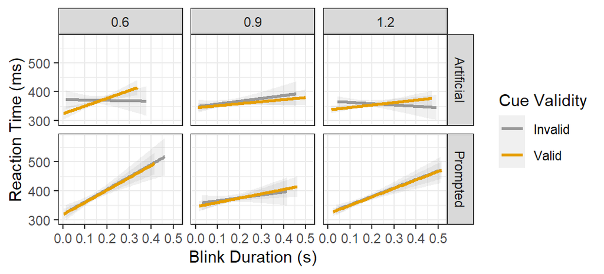

```r
p = ggplot(dsa, aes(x=bdur, y=RT, color=CueValid)) +
    stat_smooth(method='lm', alpha=0.15) +
    facet_grid(Cond~targ_soa) + guides(color=guide_legend(title='Cue Validity')) +
    xlab('Blink Duration (s)') + ylab('Reaction Time (ms)')
p = plot_themefy(p)
plot(p)
```

```r
print(lmerfn(lmer(RT ~ cue_valid_c * Cond * targ_soa * bdur + block + (1|subj), data = dsa)))
```

```
##                                            estm      se   tVal star num
## (Intercept)                             388.358  20.437 19.003  ***   0
## cue_valid_c                             -17.174  17.295 -0.993        1
## CondPrompted                             -1.429  23.173 -0.062        2
## targ_soa                                 -8.699  17.885 -0.486        3
## bdur                                      1.731 106.789  0.016        4
## block                                    -6.102   1.308 -4.665   **   5
## cue_valid_c:CondPrompted                 18.300  23.025  0.795        6
## cue_valid_c:targ_soa                      7.612  17.854  0.426        7
## CondPrompted:targ_soa                    -6.672  23.914 -0.279        8
## cue_valid_c:bdur                        118.658 104.344  1.137        9
## CondPrompted:bdur                       119.183 143.534  0.830       10
## targ_soa:bdur                           -48.726 106.274 -0.458       11
## cue_valid_c:CondPrompted:targ_soa       -10.369  23.824 -0.435       12
## cue_valid_c:CondPrompted:bdur          -162.892 142.405 -1.144       13
## cue_valid_c:targ_soa:bdur               -85.206 105.991 -0.804       14
## CondPrompted:targ_soa:bdur               14.472 144.778  0.100       15
## cue_valid_c:CondPrompted:targ_soa:bdur  131.128 144.080  0.910       16
```

The model doesn’t yield any interesting significant effects if we simply consider the raw blink duration.

### Trial-by-trial (normalized)

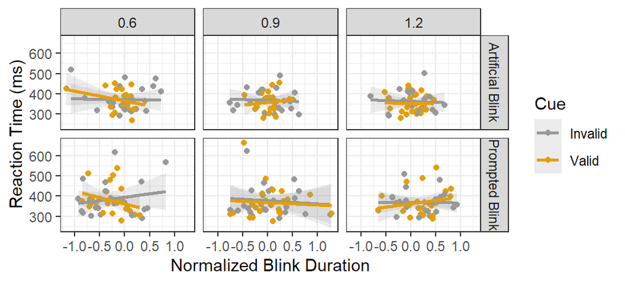

```r
bdurz_rt_cond_ctoa = ddply(dsa, .(subj, CueValid, CondFull, targ_soa), summarise,
                           RT=mean(RT), bdur_ave=mean(bdur_z))
p = ggplot(bdurz_rt_cond_ctoa, aes(x=bdur_ave, y=RT)) + geom_point(aes(color=factor(CueValid))) +
    stat_smooth(method='lm', aes(color=factor(CueValid)), alpha=.2) +
    facet_grid(CondFull~targ_soa) + xlab('Normalized Blink Duration') + ylab('Reaction Time (ms)') +
    guides(colour=guide_legend(title='Cue')) + theme_bw()
p = plot_themefy(p)
plot(p)
```

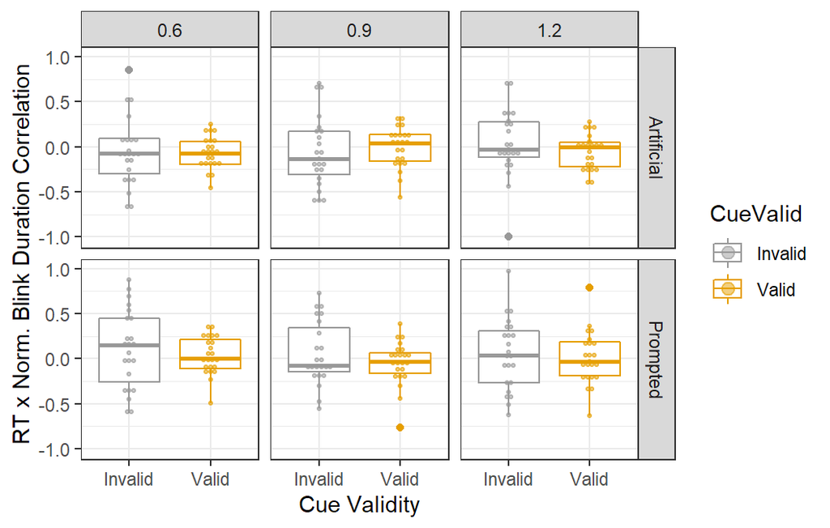

```r
cor_blink_dur_z = ddply(dsa, .(subj, CueValid, Cond, targ_soa), summarise,
                        corcoeff = cor(RT, bdur))
p = ggplot(cor_blink_dur_z, aes(x=CueValid, y=corcoeff, color=CueValid)) +
    geom_boxplot() + facet_grid(Cond~factor(targ_soa)) + xlab('Cue Validity') +
    geom_dotplot(binaxis='y', stackdir='center', dotsize=1, binwidth=.05, alpha=0.5,
                 aes(fill=CueValid)) +
    ylab('RT x Norm. Blink Duration Correlation')
p = plot_themefy(p)
if(out){outpdf('eb3_rt~bdur-z_cor', w=5.0, h=3.5, s=T)}
print(p)
```

The above plot is less informative than the one before, as it does not communicate the size of the cueing benefit for different blink durations (or any at all). But it generally comports with the only correlation of significance being: the longer the blink, the longer the RT to the invalidly cued target post-blink.

However, it does not show the negative correlation for the valid cues…

```r
print(lmerfn(lmer(RT ~ cue_valid_c * Cond * targ_soa * bdur_z + block + (1|subj), data = dsa)))
```

```
##                                             estm     se   tVal star num
## (Intercept)                              388.474 12.506 31.062  ***   0
## cue_valid_c                                0.119  6.793  0.017        1
## CondPrompted                              13.796  9.544  1.446        2
## targ_soa                                 -16.763  7.253 -2.311    *   3
## bdur_z                                   -19.705  6.822 -2.888    *   4
## block                                     -5.897  1.307 -4.512   **   5
## cue_valid_c:CondPrompted                  -7.436  9.538 -0.780        6
## cue_valid_c:targ_soa                      -4.340  7.197 -0.603        7
## CondPrompted:targ_soa                     -1.326 10.120 -0.131        8
## cue_valid_c:bdur_z                        11.181  6.792  1.646        9
## CondPrompted:bdur_z                       17.162  9.659  1.777       10
## targ_soa:bdur_z                           17.736  7.218  2.457    *  11
## cue_valid_c:CondPrompted:targ_soa         10.084 10.113  0.997       12
## cue_valid_c:CondPrompted:bdur_z          -22.264  9.615 -2.316    *  13
## cue_valid_c:targ_soa:bdur_z              -12.619  7.184 -1.757       14
## CondPrompted:targ_soa:bdur_z             -13.426 10.140 -1.324       15
## cue_valid_c:CondPrompted:targ_soa:bdur_z  22.873 10.097  2.265    *  16
```

Some interesting effects associated with trial-by-trial variation of the blink duration.

For Prompted (Real) Blink conditions:

- There is a cue validity benefit for the longer real [#13] but not artificial [#9] blink.
- The cueing benefit is specific to early CTOAs (i.e., disappears at later CTOAs) [#16].

For artificial blinks:

- Regardless of whether the target was validly cued, shorter RTs were the result of either:
  - longer blink trials [#4],
  - or larger CTOAs [#3],
  - but not both [#11].

### Individual

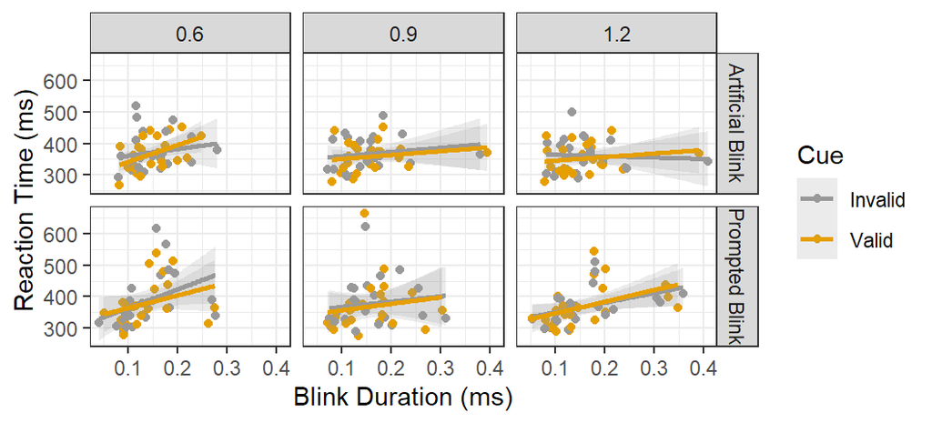

```r
bdur_rt_cond_ctoa = ddply(dsa, .(subj, CueValid, CondFull, targ_soa), summarise,
                          RT=mean(RT), bdur_ave=mean(bdur))
p = ggplot(bdur_rt_cond_ctoa, aes(x=bdur_ave, y=RT)) + geom_point(aes(color=factor(CueValid))) +
    stat_smooth(method='lm', aes(color=factor(CueValid)), alpha=.2) +
    facet_grid(CondFull~targ_soa) + xlab('Blink Duration (ms)') + ylab('Reaction Time (ms)') +
    guides(colour=guide_legend(title='Cue')) + theme_bw()
p = plot_themefy(p)
plot(p)
```

```r
merge_by = c('subj', 'CueValid', 'CondFull', 'targ_soa')
dsa_bdur = merge(dsa, bdur_rt_cond_ctoa[, c(merge_by, 'bdur_ave')], by=merge_by)
print(lmerfn(lmer(RT ~ cue_valid_c * Cond * targ_soa * bdur_ave + block + (1|subj), data = dsa)))
```

```
##                                                estm      se   tVal star num
## (Intercept)                                 301.944  23.320 12.948  ***   0
## cue_valid_c                                 -13.517  19.312 -0.700        1
## CondPrompted                                 50.357  26.337  1.912    ~   2
## targ_soa                                     38.717  20.519  1.887        3
## bdur_ave                                    559.715 128.854  4.344   **   4
## block                                        -5.848   1.298 -4.506   **   5
## cue_valid_c:CondPrompted                     -2.014  26.274 -0.077        6
## cue_valid_c:targ_soa                          0.339  20.495  0.017        7
## CondPrompted:targ_soa                       -61.407  27.937 -2.198    *   8
## cue_valid_c:bdur_ave                         88.637 116.285  0.762        9
## CondPrompted:bdur_ave                      -230.751 161.112 -1.432       10
## targ_soa:bdur_ave                          -358.945 123.646 -2.903    *  11
## cue_valid_c:CondPrompted:targ_soa            11.678  27.922  0.418       12
## cue_valid_c:CondPrompted:bdur_ave           -18.521 160.762 -0.115       13
## cue_valid_c:targ_soa:bdur_ave               -31.703 123.623 -0.256       14
## CondPrompted:targ_soa:bdur_ave              396.921 171.082  2.320    *  15
## cue_valid_c:CondPrompted:targ_soa:bdur_ave  -23.792 170.997 -0.139       16
```

## Blink latencies

### Raw

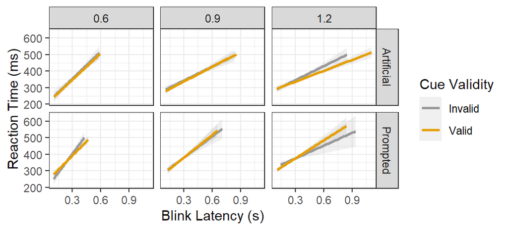

```r
p = ggplot(dsa, aes(x=blat, y=RT, color=CueValid)) +
    stat_smooth(method='lm', alpha=0.15) +
    facet_grid(Cond~targ_soa) + guides(color=guide_legend(title='Cue Validity')) +
    xlab('Blink Latency (s)') + ylab('Reaction Time (ms)')
p = plot_themefy(p)
plot(p)
```

```r
print(lmerfn(lmer(RT ~ cue_valid_c * Cond * targ_soa * blat + block + (1|subj), data = dsa)))
```

```
##                                            estm      se   tVal star num
## (Intercept)                             234.332  27.968  8.379   **   0
## cue_valid_c                              11.624  26.114  0.445        1
## CondPrompted                             -5.135  38.406 -0.134        2
## targ_soa                                 69.276  26.424  2.622    *   3
## blat                                    460.066  75.755  6.073   **   4
## block                                    -3.249   1.284 -2.530    *   5
## cue_valid_c:CondPrompted                 38.197  38.289  0.998        6
## cue_valid_c:targ_soa                    -14.116  26.353 -0.536        7
## CondPrompted:targ_soa                    11.660  39.108  0.298        8
## cue_valid_c:blat                        -31.897  75.041 -0.425        9
## CondPrompted:blat                       173.942 127.077  1.369       10
## targ_soa:blat                          -283.079  75.153 -3.767    *  11
## cue_valid_c:CondPrompted:targ_soa       -42.053  39.026 -1.078       12
## cue_valid_c:CondPrompted:blat          -173.262 126.410 -1.371       13
## cue_valid_c:targ_soa:blat                26.108  74.810  0.349       14
## CondPrompted:targ_soa:blat              -99.893 128.558 -0.777       15
## cue_valid_c:CondPrompted:targ_soa:blat  197.452 128.117  1.541       16
```

No cueing-related effects.

### Trial-by-trial (normalized)

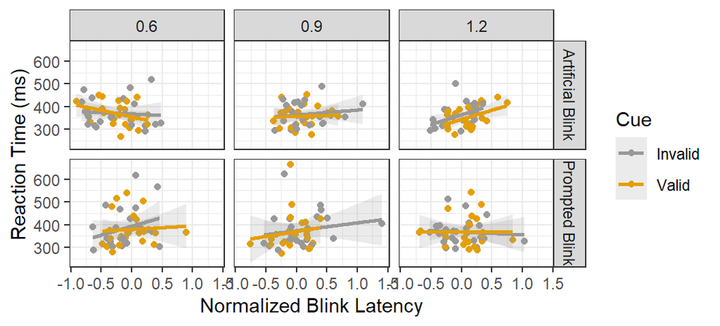

```r
blatz_rt_cond_ctoa = ddply(dsa, .(subj, CueValid, CondFull, targ_soa), summarise,
                           RT=mean(RT), blat_ave=mean(blat_z))
p = ggplot(blatz_rt_cond_ctoa, aes(x=blat_ave, y=RT)) + geom_point(aes(color=factor(CueValid))) +
    stat_smooth(method='lm', aes(color=factor(CueValid)), alpha=.2) +
    facet_grid(CondFull~targ_soa) + xlab('Normalized Blink Latency') + ylab('Reaction Time (ms)') +
    guides(colour=guide_legend(title='Cue')) + theme_bw()
p = plot_themefy(p)
plot(p)
```

```r
print(lmerfn(lmer(RT ~ cue_valid_c * Cond * targ_soa * blat_z + block + (1|subj), data = dsa)))
```

```
##                                             estm     se   tVal star num
## (Intercept)                              394.119 12.483 31.573  ***   0
## cue_valid_c                                0.514  6.753  0.076        1
## CondPrompted                               6.894  9.358  0.737        2
## targ_soa                                 -26.643  7.202 -3.699    *   3
## blat_z                                    37.216  7.581  4.909   **   4
## block                                     -3.892  1.285 -3.028    *   5
## cue_valid_c:CondPrompted                  -6.291  9.351 -0.673        6
## cue_valid_c:targ_soa                      -5.099  7.136 -0.715        7
## CondPrompted:targ_soa                      5.931  9.915  0.598        8
## cue_valid_c:blat_z                        -3.421  7.533 -0.454        9
## CondPrompted:blat_z                      -13.571 10.573 -1.284       10
## targ_soa:blat_z                          -21.974  7.728 -2.843    *  11
## cue_valid_c:CondPrompted:targ_soa          9.641  9.906  0.973       12
## cue_valid_c:CondPrompted:blat_z            1.085 10.519  0.103       13
## cue_valid_c:targ_soa:blat_z                4.673  7.684  0.608       14
## CondPrompted:targ_soa:blat_z               9.592 10.788  0.889       15
## cue_valid_c:CondPrompted:targ_soa:blat_z  -2.814 10.732 -0.262       16
```

Also no cueing-related effects, thankfully.

### Individual

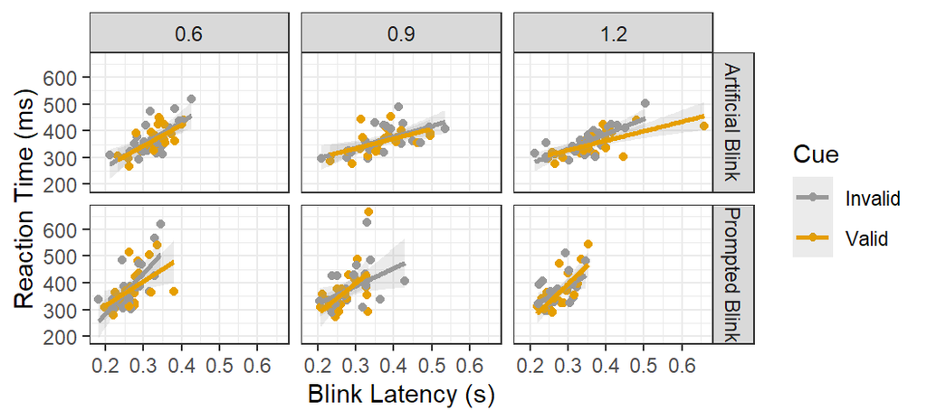

```r
blat_rt_cond_ctoa = ddply(dsa, .(subj, CueValid, CondFull, targ_soa), summarise,
                          RT=mean(RT), blat_ave=mean(blat))
p = ggplot(blat_rt_cond_ctoa, aes(x=blat_ave, y=RT)) + geom_point(aes(color=factor(CueValid))) +
    stat_smooth(method='lm', aes(color=factor(CueValid)), alpha=.2) +
    facet_grid(CondFull~targ_soa) + xlab('Blink Latency (s)') + ylab('Reaction Time (ms)') +
    guides(colour=guide_legend(title='Cue')) + theme_bw()
p = plot_themefy(p)
plot(p)
```

```r
merge_by = c('subj', 'CueValid', 'CondFull', 'targ_soa')
dsa_blat = merge(dsa, blat_rt_cond_ctoa[, c(merge_by, 'blat_ave')], by=merge_by)
print(lmerfn(lmer(RT ~ cue_valid_c * Cond * targ_soa * blat_ave + block + (1|subj), data = dsa)))
```

```
##                                                estm      se   tVal star num
## (Intercept)                                 250.747  43.155  5.810   **   0
## cue_valid_c                                 -18.239  41.115 -0.444        1
## CondPrompted                               -169.786  69.898 -2.429    *   2
## targ_soa                                     33.199  43.139  0.770        3
## blat_ave                                    395.740 118.666  3.335    *   4
## block                                        -6.089   1.337 -4.555   **   5
## cue_valid_c:CondPrompted                    198.321  67.909  2.920    *   6
## cue_valid_c:targ_soa                         22.598  43.070  0.525        7
## CondPrompted:targ_soa                        31.959  73.285  0.436        8
## cue_valid_c:blat_ave                         52.235 114.797  0.455        9
## CondPrompted:blat_ave                       777.811 236.269  3.292    *  10
## targ_soa:blat_ave                          -146.270 120.064 -1.218       11
## cue_valid_c:CondPrompted:targ_soa          -228.444  71.656 -3.188    *  12
## cue_valid_c:CondPrompted:blat_ave          -732.537 228.112 -3.211    *  13
## cue_valid_c:targ_soa:blat_ave               -76.333 119.897 -0.637       14
## CondPrompted:targ_soa:blat_ave             -154.631 247.282 -0.625       15
## cue_valid_c:CondPrompted:targ_soa:blat_ave  846.218 240.740  3.515    *  16
```

Some condition-specific effects.